# Introduksjon til GAMLSS

Fleksibel regresjon for referanseintervaller og annen moro

Per T.K. Flemmen

## Kort fortalt

- «Generalized Additive Models for Location, Scale and Shape»
- Historiske røtter i LMS-metoden utviklet på 80-tallet
- Modellerer flere fordelingsparametere $(\mu,\sigma,\nu,\tau)$
  - Alle parameterne kan følge kovariater
- Kontinuerlige referansegrenser

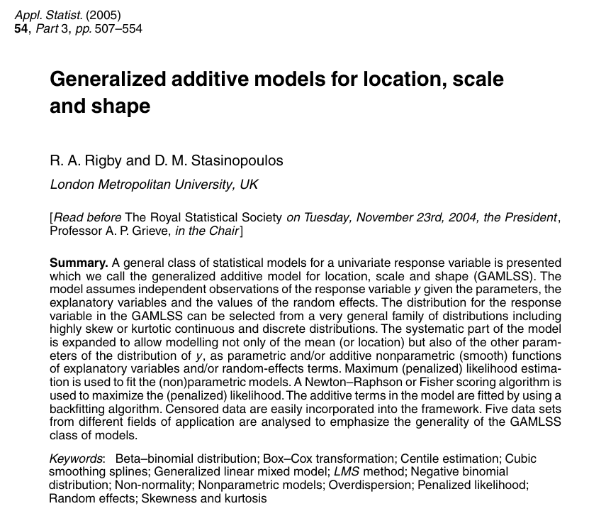

Rigby & Stasinopoulos · *JRSS C* · 2005

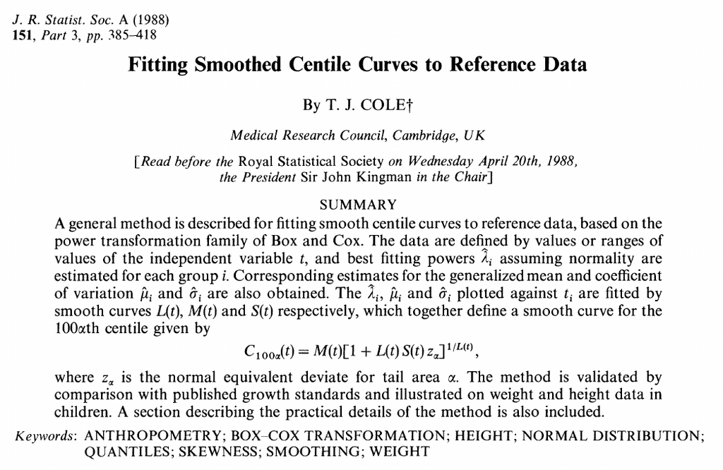

Cole · 1988 · *Fitting Smoothed Centile Curves to Reference Data*

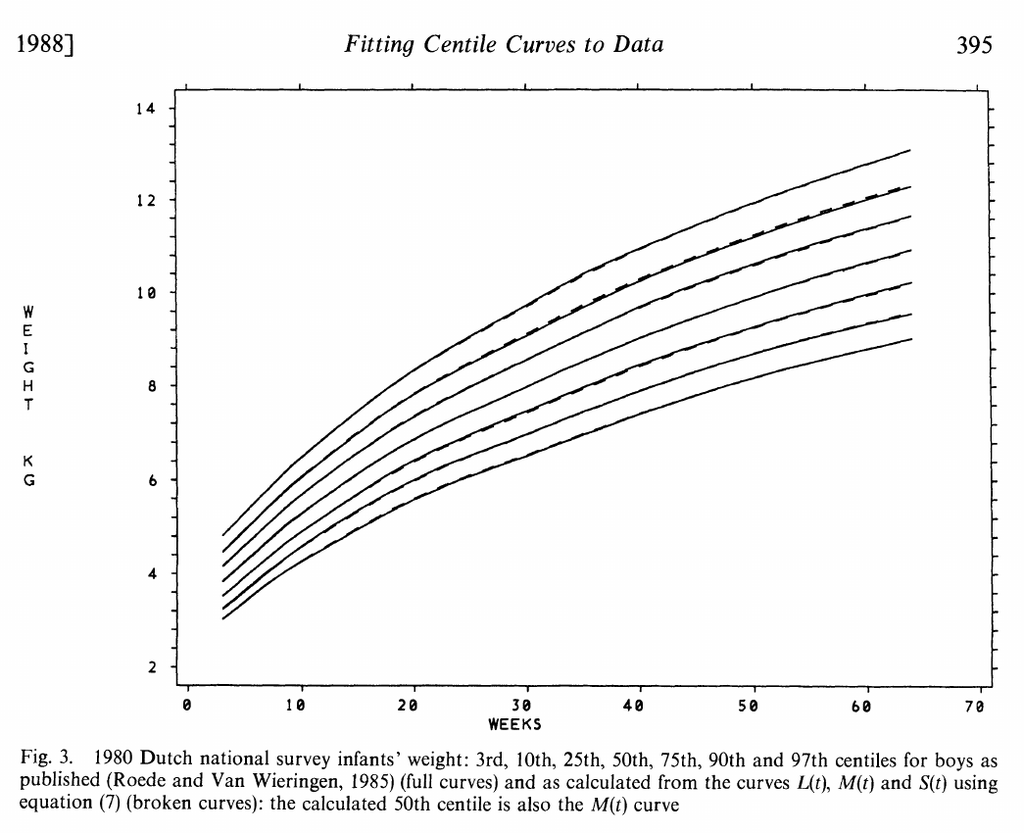

Cole · 1988 · Vektkurver for spedbarn, side 395

[figure not shown]

Mørkrid et al. · *Clinical Chemistry* · 2015

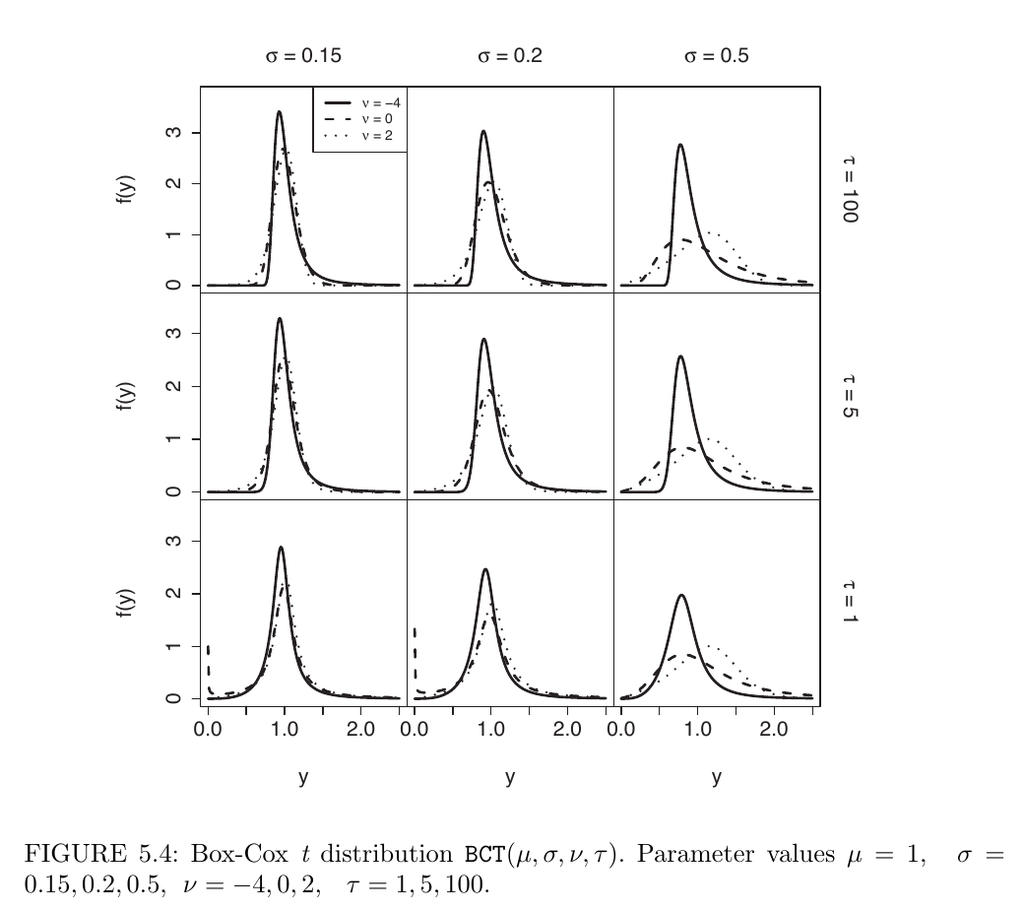

Rigby et al. · 2019 · Box–Cox t, figur 5.4

# Hva har regresjon med referansegrenser å gjøre?

## En fordeling

[figure not shown]

## Gjennomsnitt

$$\bar y=\frac{1}{n}\sum_{i=1}^{n}y_i$$

## Spredning

[figure not shown]

$$\bar y=\frac{1}{n}\sum_{i=1}^{n}y_i$$

$\displaystyle s^2=\frac{1}{n-1}\sum_{i=1}^{n}(y_i-\bar y)^2$

$P_{2{,}5},P_{97{,}5}\approx\bar y\pm1{,}96s$

## Intercept

[figure not shown]

$$Y_i=\beta_0+\varepsilon_i,
\qquad \widehat y_i=\widehat\beta_0,
\qquad e_i=y_i-\widehat y_i$$

## Samme regnestykke

Direkte estimering

Interceptregresjon

$$\textcolor{#8f2825}{\bar y}=\frac1n\sum_i y_i$$

$$\widehat\beta_0
=\operatorname*{arg\,min}_{b}\sum_i(y_i-b)^2
=\textcolor{#8f2825}{\bar y}$$

$$d_i=\textcolor{#8f2825}{y_i-\bar y}$$

$$e_i=y_i-\widehat y_i
=y_i-\widehat\beta_0
=\textcolor{#8f2825}{y_i-\bar y}$$

$$s^2=\textcolor{#8f2825}{\frac1{n-1}\sum_i(y_i-\bar y)^2}$$

$$\begin{aligned}
s_e^2
&=\frac1{n-1}\sum_i e_i^2\\
&=\textcolor{#8f2825}{\frac1{n-1}\sum_i(y_i-\bar y)^2}=s^2
\end{aligned}$$

samme sentrum · samme avstander · samme grenser

# Hvorfor trenger vi regresjon?

## Én modell bommer

[figure not shown]

## Kjønn flytter sentrum

[figure not shown]

$$\mu=\beta_0+\beta_1\,\text{kjønn}$$

## Residualene møtes

[figure not shown]

$$e_i=y_i-\widehat\mu(\text{kjønn}_i)$$

## Alder viser mønster

[figure not shown]

$\widehat\mu(a)=\widehat\beta_0$

## Én verdi til alle

[figure not shown]

$\widehat\mu(a)=\widehat\beta_0$

$\widehat\sigma(a)=\widehat\sigma_0$

$\widehat P_{2{,}5;\,97{,}5}(a)=\widehat\mu(a)\pm1{,}96\widehat\sigma(a)$

## Alder flytter nivået

[figure not shown]

$\widehat\mu(a)=\widehat\beta_0+\widehat\beta_1a$

$\widehat\sigma(a)=\widehat\sigma_0$

$\widehat P_{2{,}5;\,97{,}5}(a)=\widehat\mu(a)\pm1{,}96\widehat\sigma(a)$

## Alder flytter grensene

[figure not shown]

$\widehat\mu(a)=\widehat\beta_0+\widehat\beta_1a$

$\widehat\sigma(a)=\widehat\sigma_0$

$\widehat P_{2{,}5;\,97{,}5}(a)=\widehat\mu(a)\pm1{,}96\widehat\sigma(a)$

## Lik spredning?

[figure not shown]

$\widehat\mu(a)=\widehat\beta_0+\widehat\beta_1a$

$\widehat\sigma(a)=\widehat\sigma_0$

$\widehat P_{2{,}5;\,97{,}5}(a)=\widehat\mu(a)\pm1{,}96\widehat\sigma(a)$

## Spredningen vokser

[figure not shown]

$\widehat\mu(a)=\widehat\beta_0+\widehat\beta_1a$

$\widehat\sigma(a)=\widehat\sigma_0$

$\widehat P_{2{,}5;\,97{,}5}(a)=\widehat\mu(a)\pm1{,}96\widehat\sigma(a)$

## Scale følger alder

[figure not shown]

$\widehat\mu(a)=\widehat\beta_0+\widehat\beta_1a$

$\widehat\sigma(a)=\widehat\gamma_0+\widehat\gamma_1a$

$\widehat P_{2{,}5;\,97{,}5}(a)=\widehat\mu(a)\pm1{,}96\widehat\sigma(a)$

## Z-scorene samles

[figure not shown]

$\widehat\mu(a)=\widehat\beta_0+\widehat\beta_1a$

$\widehat\sigma(a)=\widehat\gamma_0+\widehat\gamma_1a$

$z_i=\frac{y_i-\widehat\mu(a_i)}{\widehat\sigma(a_i)}$

## Modellens z-score

$y_i$

måleresultat

→

$F_i(y_i)$

persentil

→

$\Phi^{-1}\{F_i(y_i)\}$

normalisert kvantilresidual

$$z_i=\Phi^{-1}\!\left[
F\!\left(y_i\mid\mu_i,\sigma_i,\nu_i,\tau_i\right)
\right]$$

## Normalformen er valgt

[figure not shown]

$\widehat\mu(a)=\widehat\beta_0+\widehat\beta_1a$

$\widehat\sigma(a)=\widehat\gamma_0+\widehat\gamma_1a$

$z_i=\frac{y_i-\widehat\mu(a_i)}{\widehat\sigma(a_i)}$

$(Y_i\mid A_i=a_i)\sim N\{\mu(a_i),\sigma^2(a_i)\}$

## Skjevheten blir igjen

[figure not shown]

## Skjevheten får ν

[figure not shown]

$$y\xrightarrow{\;\nu\;}y^{(\nu)}$$

## Halene er for tunge

[figure not shown]

## Halene får τ

[figure not shown]

$$\tau\longleftrightarrow\text{haletyngde}$$

## GAMLSS

$(Y_i\mid X_i=x_i)\sim\mathcal D[$

$\mu(x_i)$

location

,

$\sigma(x_i)$

scale

,

$\nu(x_i)$

skjevhet

,

$\tau(x_i)$

haler

$]$

Regresjon for hele fordelingen

## U-GAG i virkeligheten

[figure not shown]

## Worm plots

- Detrendet Q-Q-plot
- Ett panel per aldersintervall
- Flatt rundt null når modellen passer

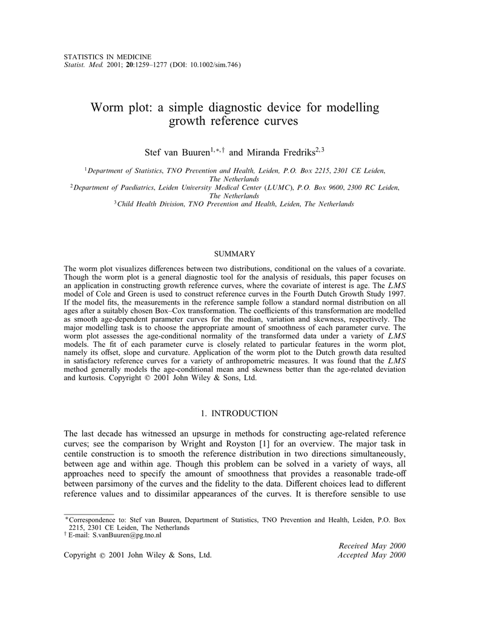

van Buuren og Fredriks. *Statistics in Medicine.*  
2001;20:1259–1277.

## Diagonalen trekkes fra

[figure not shown]

$$\text{worm-avvik}=\text{observert kvantil}-\text{forventet kvantil}$$

## Formen røper feilen

[figure not shown]

## En linje bommer

## Kurven kan være myk

$$\mu(a)=f(a)$$

glatt · datastyrt · uten aldersgrupper

## Kurven får bøye seg

[figure not shown]

## Location er ikke nok

[figure not shown]

Normal · μ(alder, kjønn) · σ

## Spredningen følger alder

[figure not shown]

Normal · μ(alder, kjønn) · σ

Normal · μ(alder, kjønn) · σ(alder)

## Skjevheten er ikke nok

[figure not shown]

Normal · μ(alder, kjønn) · σ(alder)

Box-Cox normal · μ(alder, kjønn) · σ(alder) · ν

## Halene faller på plass

[figure not shown]

Box-Cox normal · μ(alder, kjønn) · σ(alder) · ν

Box-Cox t · μ(alder, kjønn) · σ(alder) · ν · τ

## Fordelingen følger pasienten

- Referansegrenser er persentiler i en fordeling.
- Nivå, spredning og form kan variere med alder og kjønn.
- GAMLSS modellerer variasjonen; residualdiagnostikk viser hvor modellen fortsatt bommer.

## Samme tall, ulik plass

[figure not shown]